# Analysis of Germany’s Economic Data Synth function outpu commentary

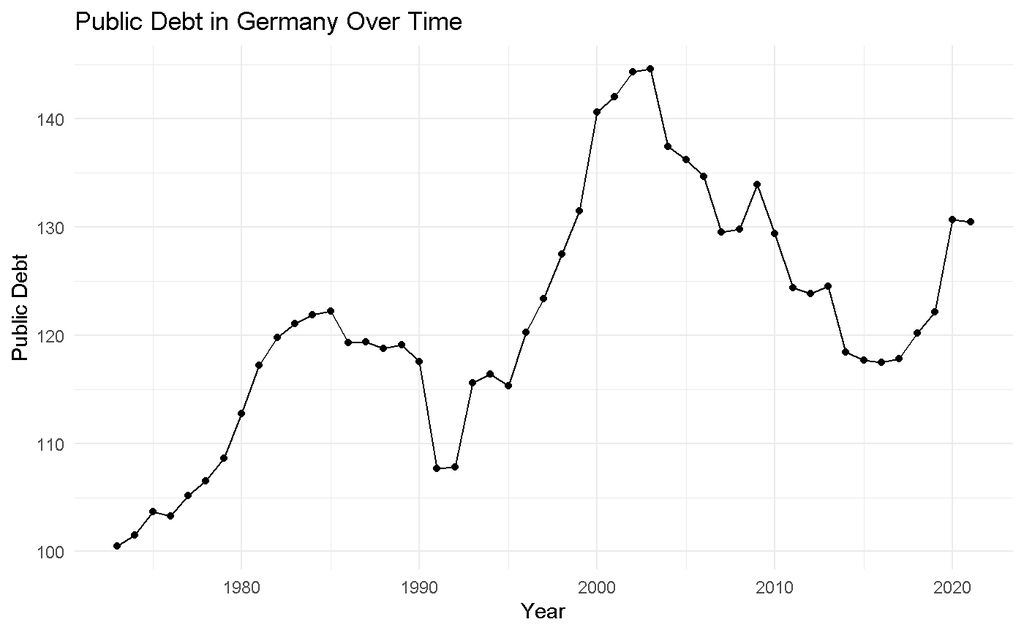

```r
# Plotting Public Debt for Germany
ggplot(germany_data, aes(x = Year, y = `Public Debt`)) +
  geom_line() +
  theme_minimal() +
  labs(title = "Public Debt in Germany Over Time", x = "Year", y = "Public Debt") +
  geom_point()
```

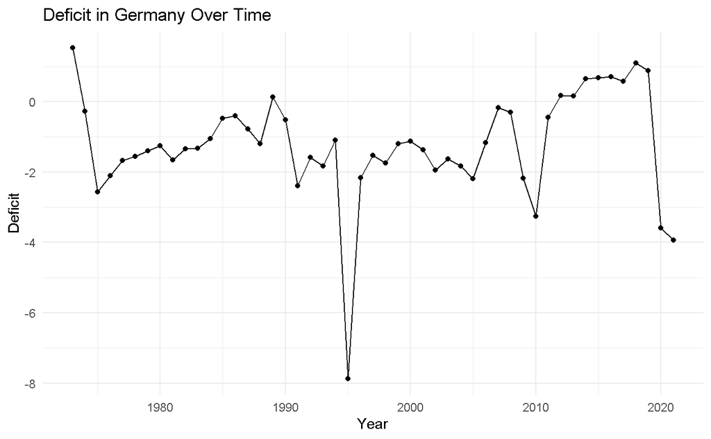

```r
# Plotting Deficit for Germany
ggplot(germany_data, aes(x = Year, y = Deficit)) +
  geom_line() +
  theme_minimal() +
  labs(title = "Deficit in Germany Over Time", x = "Year", y = "Deficit") +
  geom_point()
```

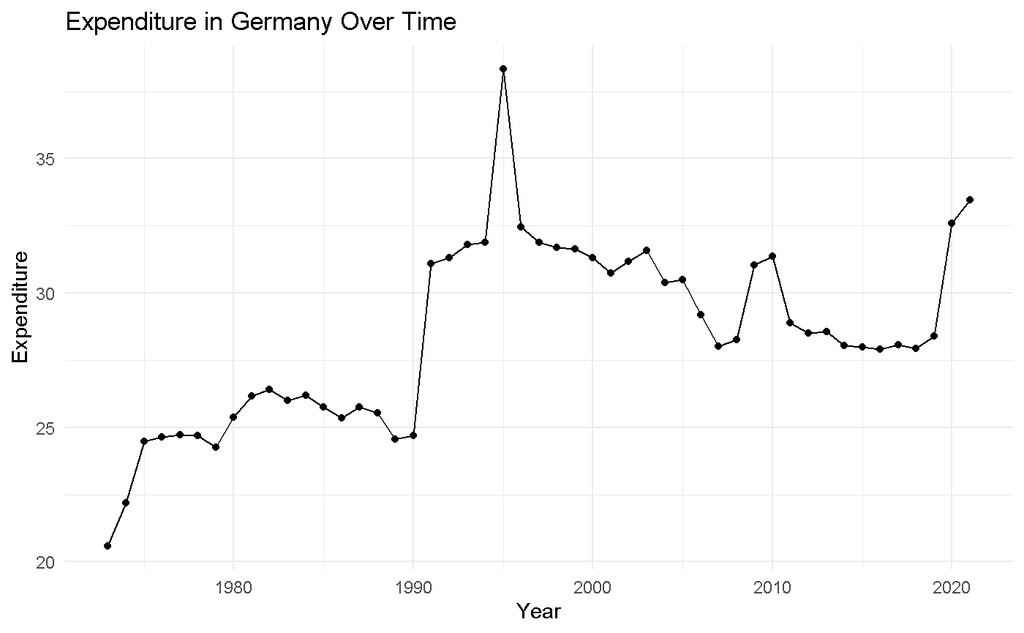

```r
# Plotting Expenditure for Germany
ggplot(germany_data, aes(x = Year, y = Expenditure)) +
  geom_line() +
  theme_minimal() +
  labs(title = "Expenditure in Germany Over Time", x = "Year", y = "Expenditure") +
  geom_point()
```

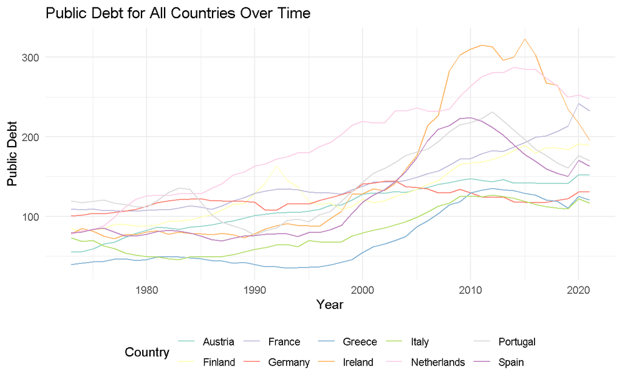

```r
# Plotting public debt for all countries over time
ggplot(long_data, aes(x = Year, y = `Public Debt`, color = Country)) +
  geom_line() +
  theme_minimal() +
  labs(title = "Public Debt for All Countries Over Time",
       x = "Year",
       y = "Public Debt",
       color = "Country") +
  theme(legend.position="bottom") +
  scale_color_brewer(palette="Set3")
```

```r
#transform to numeric
#mapping country to numeric and country name
#arrange by country


long_data$CountryNumeric <- as.numeric(as.factor(long_data$Country))

# Check the mapping between Country and Country_ID
country_mapping <- unique(long_data[, c("Country", "CountryNumeric")])


long_data <- long_data %>%
  arrange(Country, Year)



print(country_mapping)
```

| Country | CountryNumeric |
| --- | --- |
| Austria | 1 |
| Finland | 2 |
| France | 3 |
| Germany | 4 |
| Greece | 5 |
| Ireland | 6 |
| Italy | 7 |
| Netherlands | 8 |
| Portugal | 9 |
| Spain | 10 |

```r
print (long_data)
```

| Country | Year | Inflation | Imports | Public Debt | Deficit | Expenditure | CountryNumeric |
| --- | --- | --- | --- | --- | --- | --- | --- |
| Austria | 1973 | 7.53 | 27.53745 | 55.21452 | -0.83059495 | 27.61209 | 1 |
| Austria | 1974 | 9.52 | 30.45336 | 55.52718 | -0.49562294 | 27.90388 | 1 |
| Austria | 1975 | 8.45 | 28.50450 | 59.19173 | -3.24070526 | 31.10848 | 1 |
| Austria | 1976 | 7.32 | 31.16376 | 65.21788 | -3.63189512 | 31.61916 | 1 |
| Austria | 1977 | 5.49 | 32.32364 | 67.71869 | -2.99205676 | 31.41366 | 1 |
| Austria | 1978 | 3.57 | 30.55289 | 73.78815 | -3.00196643 | 33.85175 | 1 |
| Austria | 1979 | 3.71 | 32.43644 | 78.73861 | -2.61026998 | 33.32242 | 1 |
| Austria | 1980 | 6.33 | 35.13193 | 82.72654 | -2.28045171 | 33.47394 | 1 |
| Austria | 1981 | 6.80 | 35.39589 | 86.49293 | -2.25138567 | 34.56544 | 1 |
| Austria | 1982 | 5.44 | 32.37562 | 85.57855 | -3.74138547 | 34.99664 | 1 |

[output cut: 480 more lines]

```r
#check the countries in the pool

country_vector <- setNames(object = country_mapping$CountryNumeric, nm = country_mapping$Country)

print (country_vector)
```

```
    Austria     Finland      France     Germany      Greece     Ireland       Italy Netherlands
          1           2           3           4           5           6           7           8
   Portugal       Spain
          9          10
```

The code uses the `tidyverse` package to address missing values in the `long_data` dataset.

1. It groups the data by `Country` to ensure interpolations are done within each nation’s data.
2. The `approx` function performs linear interpolation, filling missing values for metrics like Inflation, Imports, etc., based on surrounding known points.
3. The data is then ungrouped and displayed.

**Purpose**: This interpolation is essential to provide a continuous dataset, which facilitates better analysis and visualization by filling gaps based on the linear relationship of known data points.

```r
library(tidyverse)

# Linear interpolation for missing values
long_data <- long_data %>%
  group_by(Country) %>%
  mutate(
    Inflation = ifelse(is.na(Inflation), approx(Year, Inflation, Year, rule = 2)$y, Inflation),
    Imports = ifelse(is.na(Imports), approx(Year, Imports, Year, rule = 2)$y, Imports),
    `Public Debt` = ifelse(is.na(`Public Debt`), approx(Year, `Public Debt`, Year, rule = 2)$y, `Public Debt`),
    Deficit = ifelse(is.na(Deficit), approx(Year, Deficit, Year, rule = 2)$y, Deficit),
    Expenditure = ifelse(is.na(Expenditure), approx(Year, Expenditure, Year, rule = 2)$y, Expenditure)
  ) %>%
  ungroup()

# Check the resulting dataframe
print(long_data)
```

| Country | Year | Inflation | Imports | Public Debt | Deficit | Expenditure | CountryNumeric |
| --- | --- | --- | --- | --- | --- | --- | --- |
| Austria | 1973 | 7.53 | 27.53745 | 55.21452 | -0.83059495 | 27.61209 | 1 |
| Austria | 1974 | 9.52 | 30.45336 | 55.52718 | -0.49562294 | 27.90388 | 1 |
| Austria | 1975 | 8.45 | 28.50450 | 59.19173 | -3.24070526 | 31.10848 | 1 |
| Austria | 1976 | 7.32 | 31.16376 | 65.21788 | -3.63189512 | 31.61916 | 1 |
| Austria | 1977 | 5.49 | 32.32364 | 67.71869 | -2.99205676 | 31.41366 | 1 |
| Austria | 1978 | 3.57 | 30.55289 | 73.78815 | -3.00196643 | 33.85175 | 1 |
| Austria | 1979 | 3.71 | 32.43644 | 78.73861 | -2.61026998 | 33.32242 | 1 |
| Austria | 1980 | 6.33 | 35.13193 | 82.72654 | -2.28045171 | 33.47394 | 1 |
| Austria | 1981 | 6.80 | 35.39589 | 86.49293 | -2.25138567 | 34.56544 | 1 |
| Austria | 1982 | 5.44 | 32.37562 | 85.57855 | -3.74138547 | 34.99664 | 1 |

[output cut: 480 more lines]

```r
NA
```

```r
#working Synth Function

# Load library

library(Synth)
long_data <- as.data.frame(long_data)



# Create the named vector from country_mapping dataframe
country_vector <- setNames(object = country_mapping$CountryNumeric, nm = country_mapping$Country)



# Prepare the data for the Synth function using the named vector
dataprep.out <- dataprep(
  foo = long_data,
  predictors = c("Deficit", "Expenditure", "Public Debt"),
  dependent = "Inflation",
  unit.variable = "CountryNumeric",
  time.variable = "Year",
  special.predictors = list(
    list("Inflation", 1980:2011, "mean"),
    list("Deficit", 1980:2011, "mean"),
    list("Public Debt", 1980:2011, "mean"),
    list("Expenditure", 1980:2011, "mean")
  ),
  treatment.identifier = country_vector["Germany"],  # Germany's numeric ID
  controls.identifier = country_vector[names(country_vector) != "Germany"],  # Numeric IDs of countries other than Germany
  time.predictors.prior = 1980:2011,
  time.optimize.ssr = 1980:2020,
  time.plot = 1980:2020,
  unit.names.variable = "Country"
)
```

```r
# Load the necessary library
library(Synth)

# Compute the synthetic control using the dataprep output
synth.out <- synth(data.prep.obj = dataprep.out)
```

```
X1, X0, Z1, Z0 all come directly from dataprep object.


****************
 searching for synthetic control unit


****************
****************
****************

MSPE (LOSS V): 1.699446

solution.v:
 0.2100359 1.912e-07 0.3050237 0.3577269 0.03721887 0.08998928 5.0914e-06

solution.w:
 0.4703317 0.4232437 2.489e-07 2.33e-08 1.328e-07 1.098e-07 0.1064239 4.47e-08 9.55e-08
```

```r
# Create synthetic tables to summarize the results
synth.tables <- synth.tab(
  dataprep.res = dataprep.out,
  synth.res = synth.out
)

# Display the synthetic tables
print(synth.tables)
```

```
$tab.pred
                              Treated Synthetic Sample Mean
Deficit                        -1.527    -1.856      -4.470
Expenditure                    29.261    38.547      39.028
Public Debt                   125.032   125.633     119.948
special.Inflation.1980.2011     2.301     3.069       5.261
special.Deficit.1980.2011      -1.527    -1.856      -4.470
special.Public Debt.1980.2011 125.032   125.633     119.948
special.Expenditure.1980.2011  29.261    38.547      39.028

$tab.v
                              v.weights
Deficit                       0.21
Expenditure                   0
Public Debt                   0.305
special.Inflation.1980.2011   0.358
special.Deficit.1980.2011     0.037
special.Public Debt.1980.2011 0.09
special.Expenditure.1980.2011 0

$tab.w
   w.weights  unit.names unit.numbers
1      0.470     Austria            1
2      0.423     Finland            2
3      0.000      France            3
5      0.000      Greece            5
6      0.000     Ireland            6
7      0.000       Italy            7
8      0.106 Netherlands            8
9      0.000    Portugal            9
10     0.000       Spain           10

$tab.loss
         Loss W   Loss V
[1,] 0.03154519 1.699446
```

Overview:

The output details the results from a Synthetic Control Method (SCM) analysis. The goal of SCM is to create a synthetic control (or a weighted combination of control units) that best approximates the characteristics of a treated unit in the pre-treatment period. The idea is to then use this synthetic control to predict the outcome of the treated unit in the post-treatment period if it had not been treated.

Findings:

Predictor Weights (solution.v):

The weights (v.weights) assigned to each predictor when constructing the synthetic control are:

Deficit: 21% Expenditure: 0% (suggesting it wasn’t deemed important for constructing the synthetic control in this instance) Public Debt: 30.5% special.Inflation.1980.2011: 35.8% special.Deficit.1980.2011: 3.7% special.Public Debt.1980.2011: 9% special.Expenditure.1980.2011: 0% The weights reveal which predictors are most influential in constructing the synthetic control. Here, special.Inflation.1980.2011 is the most influential predictor followed by Public Debt.

Synthetic Control Weights (solution.w):

The weights show how each control unit contributes to the formation of the synthetic control:

Austria: 47% Finland: 42.3% Netherlands: 10.6% Other countries like France, Greece, Ireland, Italy, Portugal, and Spain have zero or negligible weights, implying they do not contribute to the synthetic control for Germany.

This suggests that the economic behaviors of Austria, Finland, and the Netherlands (in the specified predictors) most closely resemble that of Germany in the pre-treatment period.

Predicted Values (tab.pred):

For each variable, we have values for the Treated unit (Germany), the Synthetic control, and the Sample Mean:

For Deficit, the synthetic control predicts a value of -1.856 compared to Germany’s actual value of -1.527. Expenditure is predicted at 38.547 compared to Germany’s 29.261. Similarly, other variables can be compared. The closer the synthetic values are to Germany’s actual values in the pre-treatment period, the better the synthetic control approximates Germany.

Mean Squared Prediction Errors (MSPE):

The MSPE (LOSS V) is 1.699446. This is a measure of the difference between the actual values of Germany and the synthetic control’s predictions in the pre-treatment period. A lower MSPE indicates a good fit of the synthetic control.

Losses (tab.loss):

Loss in W and V are metrics to evaluate the goodness of fit of the synthetic control. They are measures of how well the synthetic control approximates the treated unit in the pre-treatment period. In this case, the Loss W is 0.03154519, and the Loss V is 1.699446.

Conclusion:

The SCM analysis has provided a synthetic control for Germany using a combination of Austria, Finland, and the Netherlands. The chosen predictors and their weights show which economic indicators were deemed most important for this approximation. The MSPE and loss values can be used to assess the accuracy of the synthetic control in replicating Germany’s economic behavior in the pre-treatment period. The results can be used to make post-treatment predictions and infer causal effects.

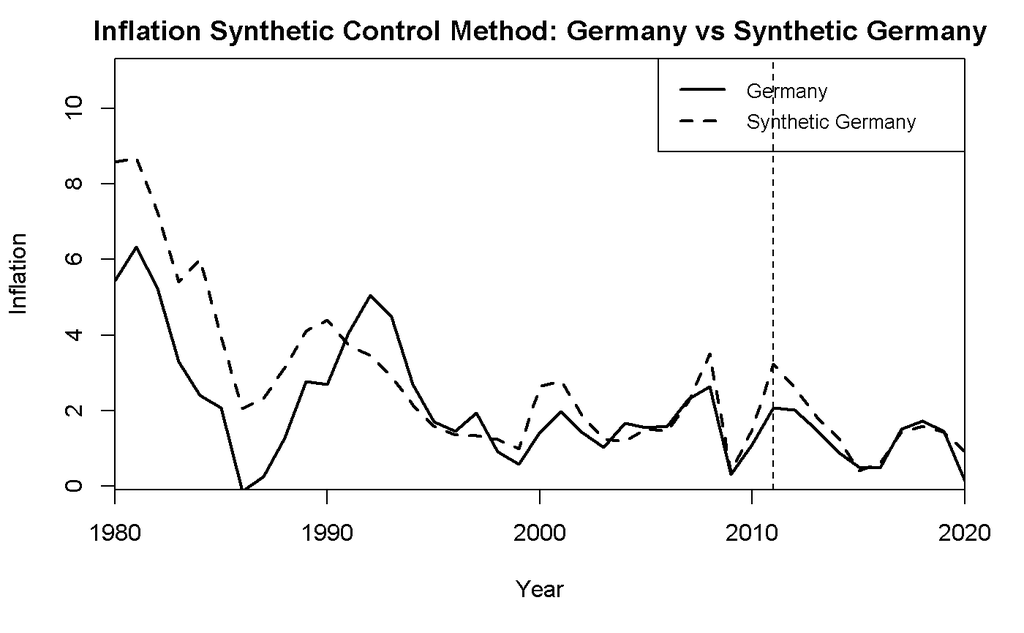

```r
path.plot(
  synth.res = synth.out,
  dataprep.res = dataprep.out,
  Ylab = "Inflation",
  Xlab = "Year",
  Legend = c("Germany","Synthetic Germany"),
  Main = "Inflation Synthetic Control Method: Germany vs Synthetic Germany"
)

# Assuming you want to add a vertical line at year 2011 when the Euro was introduced:
abline(v = 2011, lty = 2)
```

Inflation Synthetic Control Method Plot Analysis:

The plot illustrates the inflation trends in Germany versus a synthetic version of Germany constructed using the Synthetic Control Method over the span of 40 years (1980-2020).

Consistency in Pre-treatment Period:

Both Germany and Synthetic Germany experienced a pronounced peak in inflation around the late 1980s and early 1990s. This might be indicative of some global economic events or specific events related to Germany during that time. After this peak, there’s a sharp decline in inflation for both until the mid-1990s. Subsequently, the inflation rates stabilize, oscillating between 0 to 4 until 2010. Post-2010 Divergence: